# CS830 assignment Final (1)

## How accurately can we predict the popularity score of a song?

This project aims to predict the popularity score of songs using data from Spotify. The focus is on understanding and applying various machine learning algorithms, interpreting their results, and providing insights into their performance. The approach will include data understanding, preparation, model selection, and critical interpretation of results using Python and Scikit-learn.

The original dataset can be found on Kaggle: https://www.kaggle.com/datasets/cnic92/spotify-past-decades-songs-50s10s?resource=download

The popularity score is a continuous numerical variable. Regression analysis is specifically designed to predict continuous outcomes, making it a natural choice for this problem. Regression analysis helps in understanding the relationships between the dependent variable (popularity score) and the independent variables (song attributes). This insight is valuable for identifying which features most influence a song's popularity. Some regression models, like Linear Regression, offer interpretability, allowing us to understand the contribution of each feature to the predicted popularity score. This interpretability is beneficial for making informed decisions based on the model's output. Additionally, regression models can be continuously improved with additional data and feature engineering. As more data becomes available, the models can be retrained to enhance their predictive accuracy, ensuring that the predictions remain relevant and reliable.

Regression analysis is a powerful and appropriate technique for predicting the popularity of songs because of its ability to handle continuous target variables, provide insights into feature relationships, and offer high predictive accuracy. This approach aligns well with the objectives of understanding and predicting song popularity, making it a suitable choice for this analysis.

### Importing and combining the data

As the data is spread across seven CSV files we need to firstly combine these files. Utilising the pandas library allows us to merge multiple CSV files into a single dataframe. It specifically targets a designated directory, reads each CSV file, appends them into a list of dataframes, and then concatenates them into one comprehensive dataframe. This combined dataframe is then saved to a new CSV file within the same directory. The script streamlines the process of aggregating data from various files, making it simpler to manage and analyze the data effectively.

```python
import pandas as pd

directory = "C:\\Users\\User\\Desktop\\CS830 Machine learning\\Assignment"

# List to hold the dataframes
dfs = []

# Loop through all CSV files in the directory
for filename in os.listdir(directory):
    if filename.endswith(".csv"):
        file_path = os.path.join(directory, filename)
        dfs.append(pd.read_csv(file_path))

# Concatenate all dataframes
combined_df = pd.concat(dfs, ignore_index=True)

# Save the combined dataframe to a new CSV file
combined_df.to_csv("C:\\Users\\User\\Desktop\\CS830 Machine learning\\Assignment\\combined_file.csv", index=False)
```

```python
import pandas as pd
import numpy as np
import matplotlib.pyplot as plt
import seaborn as sns
from scipy.stats import skew

from sklearn.model_selection import train_test_split, GridSearchCV
from sklearn.preprocessing import StandardScaler, OneHotEncoder
from sklearn.compose import ColumnTransformer
from sklearn.pipeline import Pipeline
from sklearn.linear_model import LinearRegression
from sklearn.ensemble import RandomForestRegressor
from sklearn.metrics import mean_absolute_error, mean_squared_error, r2_score
from sklearn.model_selection import train_test_split, GridSearchCV
from sklearn.preprocessing import StandardScaler, OneHotEncoder
from sklearn.compose import ColumnTransformer
from sklearn.pipeline import Pipeline
from sklearn.ensemble import GradientBoostingRegressor
from sklearn.metrics import mean_absolute_error, mean_squared_error, r2_score
```

Reading in the combined csv using pandas

```python
df = pd.read_csv("C:\\Users\\User\\Desktop\CS830 Machine learning\\Assignment\\combined_file.csv")
```

### Data handling

Looking at an overview of our data we see that there are 667 rows and 15 columns

```python
df
```

|  | Number | title | artist | top genre | year | bpm | nrgy | dnce | dB | live | val | dur | acous | spch | pop |
| --- | --- | --- | --- | --- | --- | --- | --- | --- | --- | --- | --- | --- | --- | --- | --- |
| 0 | 1 | Put Your Head On My Shoulder | Paul Anka | adult standards | 2000 | 116 | 34 | 55 | -9 | 10 | 47 | 155 | 75 | 3 | 72 |
| 1 | 2 | Whatever Will Be Will Be (Que Sera Sera) (with... | Doris Day | adult standards | 1948 | 177 | 34 | 42 | -11 | 72 | 78 | 123 | 86 | 4 | 62 |
| 2 | 3 | Everybody Loves Somebody | Dean Martin | adult standards | 2013 | 81 | 49 | 26 | -9 | 34 | 40 | 162 | 81 | 4 | 61 |
| 3 | 4 | Take Good Care Of My Baby - 1990 Remastered | Bobby Vee | adult standards | 2011 | 82 | 43 | 49 | -12 | 12 | 66 | 151 | 70 | 6 | 60 |
| 4 | 5 | A Teenager In Love | Dion & The Belmonts | adult standards | 1959 | 79 | 38 | 56 | -9 | 13 | 62 | 158 | 67 | 3 | 60 |
| ... | ... | ... | ... | ... | ... | ... | ... | ... | ... | ... | ... | ... | ... | ... | ... |
| 662 | 96 | Stereo Hearts (feat. Adam Levine) | Gym Class Heroes | dance pop | 2011 | 90 | 80 | 65 | -3 | 27 | 80 | 211 | 3 | 10 | 56 |
| 663 | 97 | Dynamite | Taio Cruz | dance pop | 2011 | 120 | 79 | 76 | -4 | 3 | 87 | 203 | 0 | 8 | 56 |
| 664 | 98 | Break Your Heart | Taio Cruz | dance pop | 2011 | 122 | 89 | 67 | -5 | 24 | 68 | 185 | 0 | 3 | 54 |
| 665 | 99 | Summer Air | ItaloBrothers | dance pop | 2017 | 102 | 75 | 76 | -4 | 8 | 49 | 184 | 6 | 7 | 43 |
| 666 | 100 | All I Wanna Do | Martin Jensen | big room | 2016 | 112 | 79 | 73 | -4 | 7 | 56 | 194 | 16 | 7 | 32 |

667 rows × 15 columns

Below we can view the types of data included in the data frame

```python
df.info()
```

```
<class 'pandas.core.frame.DataFrame'>
RangeIndex: 667 entries, 0 to 666
Data columns (total 15 columns):
 #   Column     Non-Null Count  Dtype
---  ------     --------------  -----
 0   Number     667 non-null    int64
 1   title      667 non-null    object
 2   artist     667 non-null    object
 3   top genre  651 non-null    object
 4   year       667 non-null    int64
 5   bpm        667 non-null    int64
 6   nrgy       667 non-null    int64
 7   dnce       667 non-null    int64
 8   dB         667 non-null    int64
 9   live       667 non-null    int64
 10  val        667 non-null    int64
 11  dur        667 non-null    int64
 12  acous      667 non-null    int64
 13  spch       667 non-null    int64
 14  pop        667 non-null    int64
dtypes: int64(12), object(3)
memory usage: 78.3+ KB
```

Displaying descriptive statistics can provide us with useful insights into the range and mean counts within our numerical variables.

```python
display(df.describe())
```

|  | Number | year | bpm | nrgy | dnce | dB | live | val | dur | acous | spch | pop |
| --- | --- | --- | --- | --- | --- | --- | --- | --- | --- | --- | --- | --- |
| count | 667.000000 | 667.000000 | 667.000000 | 667.000000 | 667.000000 | 667.000000 | 667.000000 | 667.000000 | 667.000000 | 667.000000 | 667.000000 | 667.000000 |
| mean | 48.718141 | 1994.967016 | 119.121439 | 61.394303 | 60.325337 | -8.356822 | 18.188906 | 57.311844 | 224.002999 | 29.917541 | 6.179910 | 63.349325 |
| std | 28.414748 | 17.771374 | 25.030827 | 21.703963 | 15.051583 | 3.659509 | 14.380929 | 24.400412 | 59.742591 | 28.865081 | 6.191199 | 13.725845 |
| min | 1.000000 | 1945.000000 | 62.000000 | 6.000000 | 18.000000 | -24.000000 | 2.000000 | 6.000000 | 98.000000 | 0.000000 | 2.000000 | 26.000000 |
| 25% | 24.000000 | 1980.000000 | 101.500000 | 45.000000 | 51.000000 | -11.000000 | 9.000000 | 39.000000 | 185.000000 | 6.000000 | 3.000000 | 56.000000 |
| 50% | 48.000000 | 1998.000000 | 120.000000 | 64.000000 | 62.000000 | -8.000000 | 13.000000 | 58.000000 | 218.000000 | 19.000000 | 4.000000 | 66.000000 |
| 75% | 72.000000 | 2010.000000 | 134.000000 | 79.000000 | 71.000000 | -6.000000 | 24.000000 | 78.000000 | 254.000000 | 52.000000 | 6.000000 | 73.500000 |
| max | 105.000000 | 2019.000000 | 199.000000 | 100.000000 | 96.000000 | -1.000000 | 93.000000 | 99.000000 | 511.000000 | 100.000000 | 47.000000 | 94.000000 |

It's important to check the data for any missing values.

```python
missing_values = df.isnull().sum()
print("Missing values:\n", missing_values)
```

```
Missing values:
 Number        0
title         0
artist        0
top genre    16
year          0
bpm           0
nrgy          0
dnce          0
dB            0
live          0
val           0
dur           0
acous         0
spch          0
pop           0
dtype: int64
```

As there are 16 missing values within our categorical variable 'top genre', filling these values with 'Unknown' allows for preservation of the data whereas deleting rows would reduce the dataset size, potentially losing valuable information from other columns. This approach retains the row's information while acknowledging that the genre information is missing. Using a placeholder like 'Unknown' maintains consistency in the categorical data, ensuring that the dataset remains robust for analysis and modeling. When one-hot encoding is applied, 'Unknown' will be treated as another category.

```python
df['top genre'] = df['top genre'].fillna('Unknown')
```

After filling the missing values, it is crucial to verify that there are no remaining missing values and that the shape of the dataset remains unchanged.

```python
#Double check missing values have been dealt with
missing_values = df.isnull().sum()
print(missing_values)
#Check to make sure we still have the same amount of rows and columns
print(df.shape)
```

```
Number       0
title        0
artist       0
top genre    0
year         0
bpm          0
nrgy         0
dnce         0
dB           0
live         0
val          0
dur          0
acous        0
spch         0
pop          0
dtype: int64
(667, 15)
```

When dealing with duplicates in the dataset it's essential to distinguish between true duplicates and re-releases or different versions of the same song. The approach taken here ensures that we retain the earliest relevant data while avoiding redundant information. Using the earliest release year provides a consistent and logical approach to dealing with duplicates. It avoids potential confusion and ensures that the analysis is based on the song's first appearance in the market. By dropping duplicate rows based on the combination of title, artist, and year, we ensure that only unique records are kept.

```python
duplicate_titles = df[df.duplicated('title', keep=False)]

print("Duplicate song titles indicating potential re-releases:")
print(duplicate_titles[['title', 'artist', 'year']])
```

```
Duplicate song titles indicating potential re-releases:
                                           title            artist  year
0                   Put Your Head On My Shoulder         Paul Anka  2000
2                       Everybody Loves Somebody       Dean Martin  2013
3    Take Good Care Of My Baby - 1990 Remastered         Bobby Vee  2011
81                  Put Your Head On My Shoulder         Paul Anka  2000
87                            Please Mr. Postman   The Marvelettes  1961
97   Take Good Care Of My Baby - 1990 Remastered         Bobby Vee  2011
131                     Everybody Loves Somebody       Dean Martin  2014
212                    Guilty (feat. Barry Gibb)  Barbra Streisand  1980
232                           Please Mr. Postman        Carpenters  1975
318                                Hurts So Good   John Mellencamp  1982
329                    Guilty (feat. Barry Gibb)  Barbra Streisand  1980
444                              Please Don't Go        Double You  1992
477                                 Hall of Fame        The Script  2012
481                                     Dynamite         Taio Cruz  2010
491                              Let Me Love You             Mario  2004
519                             Break Your Heart         Taio Cruz  2010
596                              Let Me Love You          DJ Snake  2016
615                                 Hall of Fame        The Script  2012
624                              Please Don't Go        Joel Adams  2015
651                                Hurts So Good          Astrid S  2016
663                                     Dynamite         Taio Cruz  2011
664                             Break Your Heart         Taio Cruz  2011
```

```python
df['year'] = df.groupby(['title', 'artist'])['year'].transform('min')

df = df.drop_duplicates(subset=['title', 'artist', 'year'])

print("DataFrame after handling re-released songs:")
print(df[['title', 'artist', 'year']].drop_duplicates().head())
```

```
DataFrame after handling re-released songs:
                                               title               artist  \
0                       Put Your Head On My Shoulder            Paul Anka
1  Whatever Will Be Will Be (Que Sera Sera) (with...            Doris Day
2                           Everybody Loves Somebody          Dean Martin
3        Take Good Care Of My Baby - 1990 Remastered            Bobby Vee
4                                 A Teenager In Love  Dion & The Belmonts

   year
0  2000
1  1948
2  2013
3  2011
4  1959
```

```python
df = df.drop(columns=['title', 'Number'])

print(df.head())
```

```
                artist        top genre  year  bpm  nrgy  dnce  dB  live  val  \
0            Paul Anka  adult standards  2000  116    34    55  -9    10   47
1            Doris Day  adult standards  1948  177    34    42 -11    72   78
2          Dean Martin  adult standards  2013   81    49    26  -9    34   40
3            Bobby Vee  adult standards  2011   82    43    49 -12    12   66
4  Dion & The Belmonts  adult standards  1959   79    38    56  -9    13   62

   dur  acous  spch  pop
0  155     75     3   72
1  123     86     4   62
2  162     81     4   61
3  151     70     6   60
4  158     67     3   60
```

To ensure the effectiveness of our regression models, the 'artist' column was carefully evaluated due to its potential high cardinality. High cardinality columns can introduce noise and complexity, particularly when they contain a large number of unique values that appear infrequently. Such columns can lead to increased dimensionality of the dataset when one-hot encoding is applied, potentially resulting in overfitting and reduced model performance.

We began by analyzing the distribution of the 'artist' column to understand the number of unique artists and their frequencies. The dataset contained a total of 469 unique artists, with the top 10 most frequent artists listed for reference.

To mitigate the issues associated with high cardinality, we set a threshold of 100 unique artists. If the number of unique artists exceeded this threshold, we decided to drop the 'artist' column. This threshold is adjustable based on the specific characteristics of the dataset and the problem at hand. In our case, since the number of unique artists was 469, we opted to drop the column to simplify the model and avoid potential overfitting.

By addressing high cardinality in this manner, we aimed to create a more manageable and effective dataset for regression modeling.

```python
# Check the distribution of the 'artist' column
artist_distribution = df['artist'].value_counts()
num_unique_artists = artist_distribution.shape[0]

print(f"Number of unique artists: {num_unique_artists}")
print("Top 10 most frequent artists:")
print(artist_distribution.head(10))

# Decide whether to drop the 'artist' column
if num_unique_artists > 100:
    print("Dropping the 'artist' column due to high cardinality.")
    df = df.drop(columns=['artist'])
else:
    print("Keeping the 'artist' column.")
```

```
Number of unique artists: 469
Top 10 most frequent artists:
artist
Elton John          12
Queen               11
ABBA                 9
The Beatles          7
Rihanna              6
Whitney Houston      6
Mariah Carey         5
Taylor Swift         5
Post Malone          5
Barbra Streisand     5
Name: count, dtype: int64
Dropping the 'artist' column due to high cardinality.
```

To manage the 'top genre' column effectively and ensure robust model performance, following steps were undertook:

```python
# Get the count of each genre
genre_counts = df['top genre'].value_counts()

# Print the number of unique genres
num_unique_genres = genre_counts.shape[0]
print(f"Number of unique genres: {num_unique_genres}")

# Print the counts of each genre
print(genre_counts)
```

```
Number of unique genres: 116
top genre
dance pop                 112
adult standards            89
album rock                 77
glam rock                  23
brill building pop         20
                         ...
australian talent show      1
afrobeat                    1
british blues               1
afropop                     1
aussietronica               1
Name: count, Length: 116, dtype: int64
```

To address potential issues with high cardinality and improve model stability, genres were consolidated with fewer than 20 songs into a single category labeled 'Other'. Including categories with very few samples can introduce noise and instability into the model. By setting a threshold of 20, we ensured that each genre category had a sufficient number of samples, enhancing model performance and generalizability. After consolidating low-frequency genres, we verified the changes by recalculating and printing the updated genre counts. The number of unique genres was reduced to 6, indicating successful consolidation.

```python
# Set the threshold for minimum number of songs a genre should have
threshold = 20

# Replace genres with fewer than 'threshold' songs with 'Other'
df['top genre'] = df['top genre'].apply(lambda x: x if genre_counts[x] >= threshold else 'Other')

# Get the updated count of each genre
updated_genre_counts = df['top genre'].value_counts()

# Print the updated number of unique genres
num_updated_genres = updated_genre_counts.shape[0]
print(f"Number of unique genres after consolidation: {num_updated_genres}")

# Print the counts of each updated genre
print(updated_genre_counts)
```

```
Number of unique genres after consolidation: 6
top genre
Other                 339
dance pop             112
adult standards        89
album rock             77
glam rock              23
brill building pop     20
Name: count, dtype: int64
```

To understand the temporal distribution of songs in our dataset, we conducted an analysis of the number of songs per year. This analysis helps in identifying how the dataset is spread over time and whether certain years are more represented than others.

Counting the Number of Songs per Year: We started by counting the number of songs for each year using the value_counts() function. Sorting these counts in ascending order provided a clear view of the representation of each year in the dataset.

The counts of songs per year were printed to give a textual overview of the distribution. This step helps in identifying any years with significantly higher or lower representation, which could influence the analysis.

```python
songs_per_year = df['year'].value_counts().sort_index()


print(songs_per_year)
```

```
year
1945     1
1948     1
1953     1
1957     1
1958     2
        ..
2015    12
2016    24
2017    42
2018    18
2019    15
Name: count, Length: 66, dtype: int64
```

We defined a threshold to identify years with fewer than 10 songs. This helps in making decisions about handling the 'year' column in our modeling process.

```python
threshold = 10

years_below_threshold = songs_per_year[songs_per_year < threshold].count()

print(f"Number of years with fewer than {threshold} songs: {years_below_threshold}")

if years_below_threshold > 0:
    print(f"There are {years_below_threshold} years with fewer than {threshold} songs. Consider dropping the 'year' column.")
else:
    print(f"All years have at least {threshold} songs. Keeping the 'year' column.")
```

```
Number of years with fewer than 10 songs: 37
There are 37 years with fewer than 10 songs. Consider dropping the 'year' column.
```

Through this analysis, we found that within the 75 year range there were 37 years with fewer than 10 songs. This information is crucial for making informed decisions about handling the 'year' column in our modeling process. For instance, years with very few songs might be consolidated or treated differently to ensure a more balanced dataset.

```python
df = df.drop(columns=['year'])
```

### Data visualisation

Firstly we will view the distribution of our target variable, popularity scores. Matplotlib and Seaborn can be used for this purpose. A histogram provides a visual representation of the frequency distribution of popularity scores. The Kernel Density Estimate (KDE) overlay helps in visualizing the probability density function of the variable, providing insights into its underlying distribution. Understanding this distribution and skewness can help in selecting an appropriate model.

```
Skewness of popularity scores: -0.6834168316013827
```

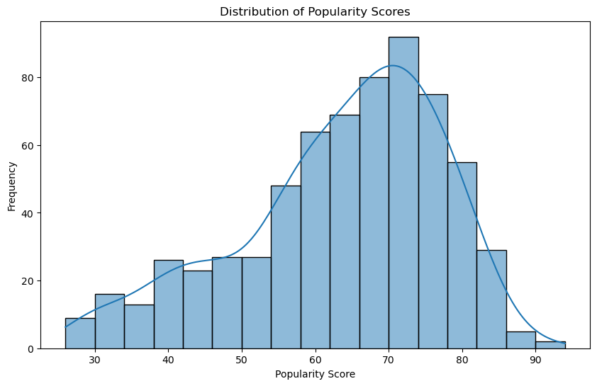

```python
pop_skewness = skew(df['pop'])
print(f'Skewness of popularity scores: {pop_skewness}')

plt.figure(figsize=(10, 6))
sns.histplot(df['pop'], kde=True)
plt.title('Distribution of Popularity Scores')
plt.xlabel('Popularity Score')
plt.ylabel('Frequency')
plt.show()
```

The histogram of the popularity scores reveals a slightly left-skewed distribution with the skewness value being -0.683. This indicates that the distribution has a longer tail on the left side. The KDE plot overlay helps to smooth out the histogram, providing a clearer picture of the underlying distribution.

Understanding the skewness and distribution of the target variable is crucial for model selection and evaluation. For instance, certain regression models assume normally distributed errors, and understanding the skewness helps in deciding whether transformations or specific models are required to handle the distribution effectively.

Plotting the variables allows for understanding of the underlying distribution of each numerical feature in the dataset. Knowing whether the data is normally distributed, skewed, or has outliers can guide subsequent data preprocessing steps and model selection.

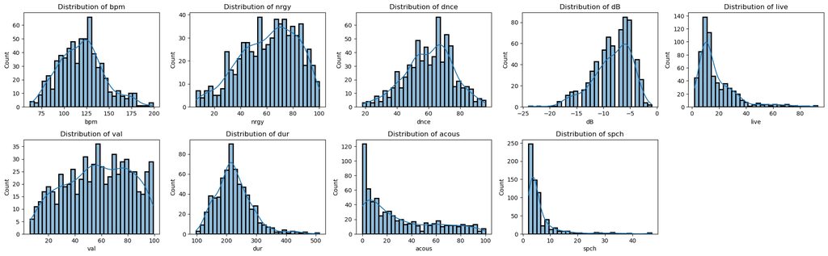

```python
numerical_features = [feature for feature in numerical_features if feature in df.columns]


plt.figure(figsize=(20, 15))
for i, feature in enumerate(numerical_features):
    plt.subplot(5, 5, i+1)
    sns.histplot(df[feature], kde=True, bins=30, edgecolor="black", linewidth=2)
    plt.title(f'Distribution of {feature}')
plt.tight_layout()
plt.show()
```

The distributions of the numerical features provide insights into the characteristics of the songs in the dataset. Understanding these distributions helps in identifying necessary data transformations, handling outliers, and selecting appropriate models. The skewness and presence of outliers in some features may require transformations to improve the accuracy and performance of predictive models.

Creating a bar chart allows for effective visualisation of the distribution of songs across different top genres in the dataset. Each bar represents the count of songs for a particular genre, with the length of the bar indicating the frequency. The 'Other' category has the highest count, signifying that many less frequent genres have been consolidated into this category. This step was necessary to manage high cardinality and ensure robust model performance. Genres like 'dance pop,' 'adult standards,' and 'album rock' have significant representation in the dataset. This indicates that these genres are prominent among the songs analyzed.

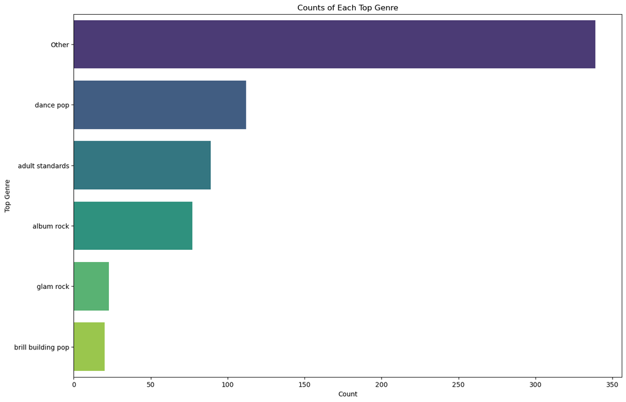

```python
plt.figure(figsize=(15, 10))
genre_counts = df['top genre'].value_counts()
sns.barplot(x=genre_counts.values, y=genre_counts.index, palette='viridis')
plt.title('Counts of Each Top Genre')
plt.xlabel('Count')
plt.ylabel('Top Genre')
plt.show()
```

This bar chart offers a clear visual summary of genre representation, revealing both dominant and less frequent genres. The high count in the 'Other' category underscores the necessity of managing high cardinality in categorical data. This step ensures that the model remains stable and prevents overfitting by avoiding too many categories with sparse data.

Using matplotlib and seaborn packages allows for visualisation of the relationships between each numerical feature and the target variable. Scatter plots help in identifying the type of relationship (linear, quadratic, exponential, etc.) between the features and the target variable. Understanding the nature of these relationships guides the choice of appropriate modeling techniques.

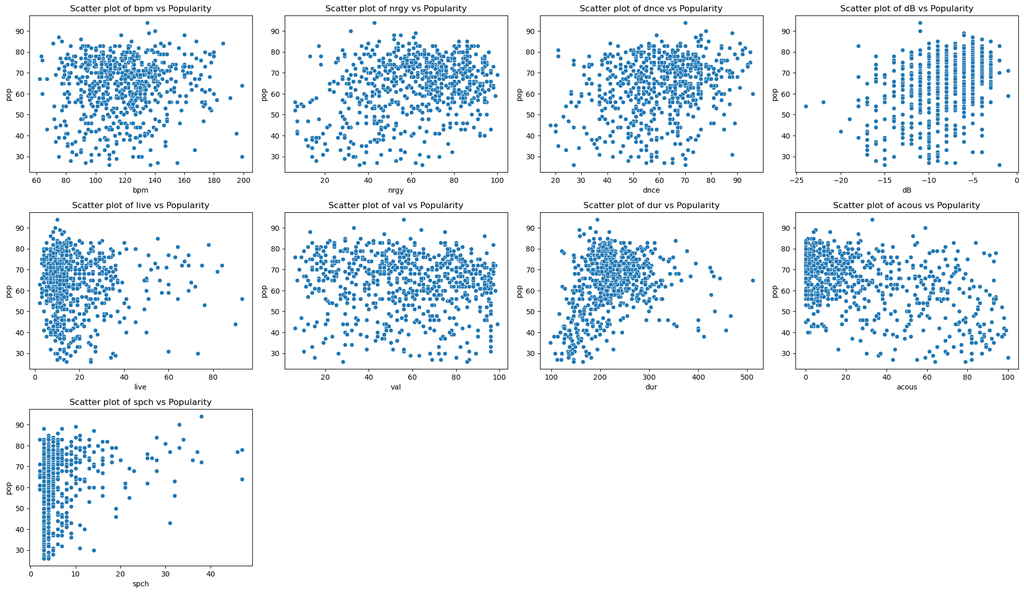

```python
numerical_features = df.select_dtypes(include=[np.number]).columns.drop('pop')

plt.figure(figsize=(20, 15))
for i, feature in enumerate(numerical_features):
    plt.subplot(4, 4, i+1)
    sns.scatterplot(data=df, x=feature, y='pop')
    plt.title(f'Scatter plot of {feature} vs Popularity')
plt.tight_layout()
plt.show()
```

Most scatter plots do not show a strong linear or non-linear relationship between the numerical features and the target variable (popularity). This indicates that the individual features alone may not be strong predictors of popularity. It highlights the need for more advanced modeling techniques that can capture complex interactions and relationships between features.

Before performing regression, analyzing a correlation heatmap is crucial for detecting multicollinearity, which occurs when predictor variables are highly correlated. Multicollinearity can lead to unstable estimates of regression coefficients, affecting model performance.

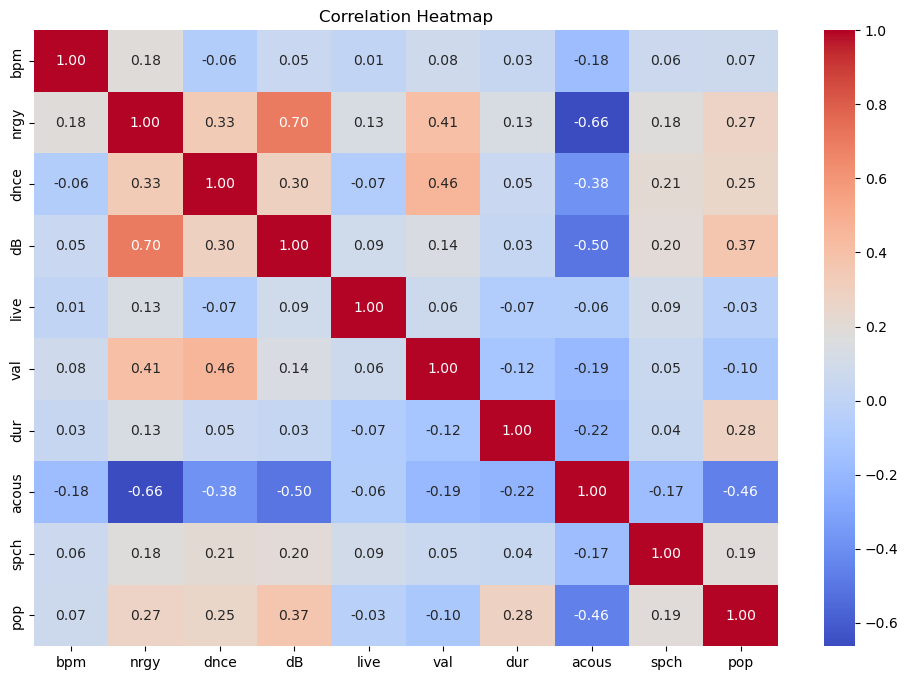

```python
numerical_cols = df.select_dtypes(include=[np.number]).columns


plt.figure(figsize=(12, 8))
sns.heatmap(df[numerical_cols].corr(), annot=True, cmap='coolwarm', fmt='.2f')
plt.title('Correlation Heatmap')
plt.show()
```

### Handling multicollinearity and preparing data for regression

Variable Inflation Factor (VIF) can be calculated to detect multicollinearity among the selected features.

```python
from statsmodels.stats.outliers_influence import variance_inflation_factor
from sklearn.linear_model import LinearRegression, Ridge, Lasso
from sklearn.model_selection import train_test_split, cross_val_score
from sklearn.preprocessing import StandardScaler

# Select only numeric columns
numeric_df = df.select_dtypes(include=[np.number])

# Step 1: Prioritize features with moderate correlations with the target variable
correlation_threshold = 0.2
correlations = numeric_df.corr()['pop'].abs()
high_correlation_features = correlations[correlations > correlation_threshold].index.drop('pop')
```

```python
def calculate_vif(df, features):
    X = df[features]
    X['intercept'] = 1
    vif = pd.DataFrame()
    vif['feature'] = features
    vif['VIF'] = [variance_inflation_factor(X.values, i) for i in range(X.shape[1] - 1)]
    return vif

vif_df = calculate_vif(df, high_correlation_features)
print(vif_df)

# Remove features with high VIF (> 10)
features_to_remove = vif_df[vif_df['VIF'] > 10]['feature'].tolist()
selected_features = [feature for feature in high_correlation_features if feature not in features_to_remove]
```

```
  feature       VIF
0    nrgy  2.645654
1    dnce  1.194454
2      dB  2.009668
3     dur  1.065971
4   acous  1.962223
```

The VIF values for the selected features (nrgy, dnce, dB, dur, acous) are all below 5, indicating that multicollinearity is not a significant issue for these features.

Standardization ensures that all features contribute equally to the model by transforming them to have a mean of 0 and a standard deviation of 1. To see if standardization is neccessary we can compare the R-squared values. The model with the higher mean cross-validation R-squared value is preferable. If standardization improves the R-squared, it indicates that scaling the features is beneficial for the model.

```python
from sklearn.linear_model import LinearRegression
from sklearn.model_selection import train_test_split, cross_val_score
from sklearn.preprocessing import StandardScaler
from sklearn.compose import ColumnTransformer
from sklearn.pipeline import Pipeline
from sklearn.impute import SimpleImputer
from sklearn.preprocessing import OneHotEncoder


# Select numerical and categorical features
numerical_features = df.select_dtypes(include=[np.number]).columns.drop('pop')
categorical_features = df.select_dtypes(include=[object]).columns

# Define preprocessor for numerical and categorical features
preprocessor = ColumnTransformer(
    transformers=[
        ('num', SimpleImputer(strategy='mean'), numerical_features),
        ('cat', OneHotEncoder(), categorical_features)
    ])

# Apply preprocessing to the entire dataset
X = preprocessor.fit_transform(df)
y = df['pop']

# Split data into training and testing sets
X_train, X_test, y_train, y_test = train_test_split(X, y, test_size=0.2, random_state=42)
```

```python
# Train model without standardization
linear_model = LinearRegression()
linear_model.fit(X_train, y_train)
cv_scores = cross_val_score(linear_model, X_train, y_train, cv=5, scoring='r2')
print(f'Mean Cross-Validation R-squared without Standardization: {np.mean(cv_scores)}')
```

```
Mean Cross-Validation R-squared without Standardization: 0.3397180356416764
```

```python
# Train model with standardization
scaler = StandardScaler()
X_train_scaled = scaler.fit_transform(X_train)
X_test_scaled = scaler.transform(X_test)

linear_model_scaled = LinearRegression()
linear_model_scaled.fit(X_train_scaled, y_train)
cv_scores_scaled = cross_val_score(linear_model_scaled, X_train_scaled, y_train, cv=5, scoring='r2')
print(f'Mean Cross-Validation R-squared with Standardization: {np.mean(cv_scores_scaled)}')
```

```
Mean Cross-Validation R-squared with Standardization: 0.33200541517371496
```

The mean cross-validation R-squared values with and without standardization are almost identical, indicating that standardization does not significantly impact the performance of your linear regression model on this dataset. This suggests that the features in your dataset do not vary widely in scale, or the linear regression model is not sensitive to the scale of these particular features.

Scaling helps in standardizing these distributions, making the model training process more stable and reliable.

```python
print(df[numerical_features].describe())
```

```
              bpm        nrgy        dnce          dB        live         val  \
count  660.000000  660.000000  660.000000  660.000000  660.000000  660.000000
mean   119.180303   61.415152   60.356061   -8.351515   18.219697   57.204545
std     25.055251   21.694396   15.086263    3.651023   14.418056   24.443965
min     62.000000    6.000000   18.000000  -24.000000    2.000000    6.000000
25%    101.750000   45.000000   51.000000  -10.250000    9.000000   38.000000
50%    120.000000   64.000000   62.000000   -8.000000   13.000000   58.000000
75%    134.000000   79.000000   71.000000   -6.000000   24.000000   78.000000
max    199.000000  100.000000   96.000000   -1.000000   93.000000   99.000000

              dur       acous        spch
count  660.000000  660.000000  660.000000
mean   224.371212   29.839394    6.193939
std     59.833964   28.777704    6.219941
min     98.000000    0.000000    2.000000
25%    185.750000    6.000000    3.000000
50%    218.000000   19.000000    4.000000
75%    254.250000   52.000000    6.000000
max    511.000000  100.000000   47.000000
```

The descriptive statistics show that the numerical features have different ranges. For example, bpm ranges from 62 to 199, nrgy ranges from 6 to 100, dur ranges from 98 to 511 and acous ranges from 0 to 100. These differences in scale can affect the performance of certain machine learning algorithms, especially those that rely on distance calculations, such as linear regression.

The standard deviations (std) of the features also vary significantly. Features with larger variance can dominate the distance calculations, leading to biased model training. Scaling ensures that each feature contributes equally.

The quartile ranges (25%, 50%, and 75%) indicate that the distributions of features like dB, live, and acous are quite different. Given the significant differences in the ranges and variances of our numerical features, scaling is necessary to ensure that each feature contributes equally to the model training process.

## Data analysis

### Linear regression

In this section, we set up our data and necessary tools for building a regression model to predict song popularity. We use several modules from the scikit-learn library, which provides a wide range of tools for machine learning and statistical modeling.

A linear regression will be used first as a baseline.

The target variable 'pop', which represents the popularity score of the songs, is separated from the rest of the dataset, we create the feature set X and the target variable y.

```python
# For fitting a linear regression
from sklearn.linear_model import LinearRegression

# For evaluating the model's performance
from sklearn.metrics import mean_absolute_error, mean_squared_error, r2_score

# Standardizes numerical features and encodes categorical features
from sklearn.preprocessing import StandardScaler, OneHotEncoder

# Splits data into training and test sets and evaluates the model
from sklearn.model_selection import train_test_split, cross_val_score

# Applies different preprocessing steps to numerical and categorical data
from sklearn.compose import ColumnTransformer

# Creates a streamlined process that integrates preprocessing and model fitting
from sklearn.pipeline import Pipeline


# Define X as the feature set by dropping the target variable (popularity scores) from the dataset.
X = df.drop(columns=['pop'])

# Define y as the target variable, which we aim to predict.
y = df['pop']
```

```python
# Identify categorical and numerical columns
categorical_cols = X.select_dtypes(include=['object', 'category']).columns
numerical_cols = X.select_dtypes(include=[np.number]).columns

# Define the preprocessing steps
preprocessor = ColumnTransformer(
    transformers=[
        ('num', StandardScaler(), numerical_features),
        ('cat', OneHotEncoder(drop='first'), categorical_features)
    ])
```

Using the split function from scikit-learn allows us to segment the dataset into training and testing sets allows us to train the model on one subset of the data (X_train, y_train) and evaluate its performance on another subset (X_test, y_test). This helps in assessing how well the model generalizes to unseen data.

Allocating a test size of 0.2 allocates 20% of the data for testing and the remaining 80% for training. Setting a random state of 42 ensures reproducibility by using a fixed seed for the random number generator, allowing for consistent results across different runs.

The use of pipelines ensures that the same preprocessing steps are applied consistently across training and testing data, which is crucial for reliable evaluation.

```python
# Split data into training and testing sets
X_train, X_test, y_train, y_test = train_test_split(X, y, test_size=0.2, random_state=42)

# Create a pipeline with preprocessing and the linear regression model
linear_regression_pipeline = Pipeline(steps=[
    ('preprocessor', preprocessor),
    ('regressor', LinearRegression())
])

# Fit the pipeline on the training data
linear_regression_pipeline.fit(X_train, y_train)

# Predict on the test set
y_pred = linear_regression_pipeline.predict(X_test)

# Evaluate the model
mae = mean_absolute_error(y_test, y_pred)
mse = mean_squared_error(y_test, y_pred)
r2 = r2_score(y_test, y_pred)

# Print the evaluation results with the model name
print(f'Linear Regression MAE: {mae}')
print(f'Linear Regression MSE: {mse}')
print(f'Linear Regression R-squared: {r2}')
```

```
Linear Regression MAE: 10.917257128559864
Linear Regression MSE: 181.12266062057915
Linear Regression R-squared: 0.23830080655950736
```

Cross-validation helps to ensure that the model's performance is consistent and not due to overfitting on the training data. It also provides a better estimate of the model's performance on unseen data.

```python
from sklearn.model_selection import cross_val_score

# Perform cross-validation
cv_scores = cross_val_score(linear_regression_pipeline, X_train, y_train, cv=5, scoring='r2')
mean_cv_r2 = np.mean(cv_scores)

print(f'Mean Cross-Validation R-squared: {mean_cv_r2}')
```

```
Mean Cross-Validation R-squared: 0.3397180356416766
```

Plotting the residuals illustrates the differences between observed and predicted values, indicating how well the model's predictions align with the actual data. The scatter plot, with fitted values on the x-axis and residuals on the y-axis, includes a horizontal red dashed line at zero as a reference. This plot helps visualize the distribution of residuals and assess the model's performance, highlighting any patterns or inconsistencies that might suggest issues such as heteroscedasticity, non-linearity, or the presence of outliers.

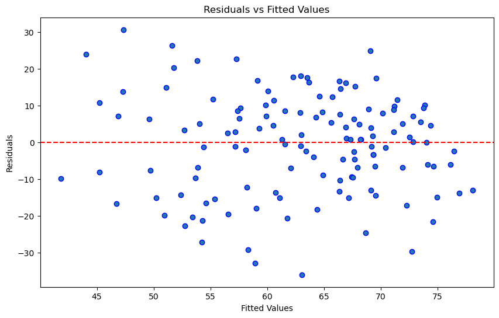

```python
# Calculate residuals
residuals = y_test - y_pred


# Residuals vs Fitted values plot
plt.figure(figsize=(10, 6))
plt.scatter(y_pred, residuals, edgecolor='blue', linewidth=1)
plt.axhline(0, color='red', linestyle='--')
plt.title('Residuals vs Fitted Values')
plt.xlabel('Fitted Values')
plt.ylabel('Residuals')
plt.show()
```

The Residuals vs. Fitted Values plot for our linear regression model shows that the residuals are randomly scattered around the horizontal axis with no distinct pattern. This indicates that our model captures the relationship between the predictors and the target variable well, and the assumption of homoscedasticity is met. However, there are a few outliers that might require further investigation. Overall, the plot suggests that our model is reasonably well-specified

### Polynomial regression

To capture the non-linear relationships inherent in the data, we can extend the linear regression model to include polynomial features.

```python
from sklearn.preprocessing import PolynomialFeatures

# Define the polynomial degree
degree = 2

# Create polynomial features
poly_features = PolynomialFeatures(degree=degree, include_bias=False)

# Create the pipeline for Polynomial Regression
pipeline_poly_lr = Pipeline(steps=[
    ('preprocessor', preprocessor),
    ('poly', poly_features),
    ('model', LinearRegression())
])
```

First we specify the degree of polynomial features, in this case 2. We then generate new features by taking the input features and creating polynomial combinations up to the specified degree. Setting include_bias=False ensures that we do not add a bias term (a column of ones) to the features, as this will be handled by the linear regression model itself.

A pipeline is then created and the polynomial regression pipeline is fitted to the training data.

```python
pipeline_poly_lr.fit(X_train, y_train)
y_pred_poly_lr = pipeline_poly_lr.predict(X_test)

mae_poly_lr = mean_absolute_error(y_test, y_pred_poly_lr)
mse_poly_lr = mean_squared_error(y_test, y_pred_poly_lr)
r2_poly_lr = r2_score(y_test, y_pred_poly_lr)

print(f'Polynomial Linear Regression MAE: {mae_poly_lr}')
print(f'Polynomial Linear Regression MSE: {mse_poly_lr}')
print(f'Polynomial Linear Regression R-squared: {r2_poly_lr}')
```

```
Polynomial Linear Regression MAE: 10.796924982630022
Polynomial Linear Regression MSE: 208.2073532434151
Polynomial Linear Regression R-squared: 0.12439794948622862
```

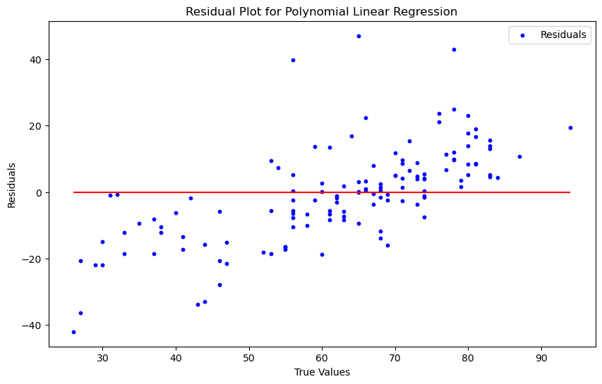

```python
plt.figure(figsize=(10, 6))
plt.scatter(y_test, y_test - y_pred_poly_lr, color='blue', s=10, label='Residuals')
plt.hlines(y=0, xmin=y_test.min(), xmax=y_test.max(), colors='red')
plt.xlabel('True Values')
plt.ylabel('Residuals')
plt.title('Residual Plot for Polynomial Linear Regression')
plt.legend()
plt.show()
```

The residuals appear to have a pattern forming. Some residuals are significantly far from zero, indicating outliers. These points represent instances where the model's predictions are far from the actual values, which could be due to the complexity of the underlying relationships or noise in the data. The patterns also suggest that there may be non-linear relationships that the polynomial features are not adequately addressing.

A learning curve can help us better understand how the polynomial model is fitting the data.

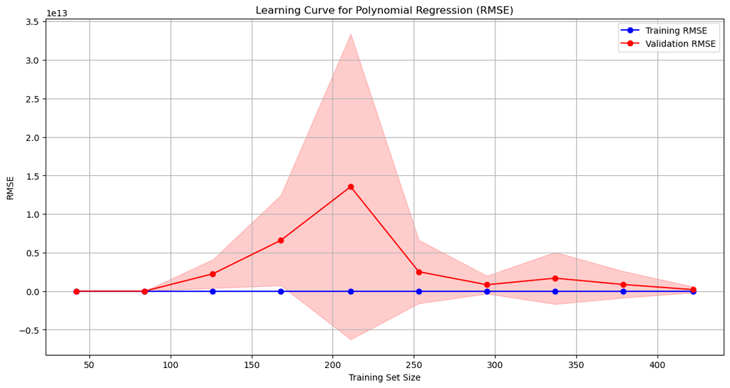

```python
from sklearn.model_selection import learning_curve
from sklearn.metrics import make_scorer, mean_squared_error

# Define RMSE scoring
rmse_scorer = make_scorer(mean_squared_error, squared=False)

# Generate learning curve data with RMSE scoring
train_sizes, train_scores, validation_scores = learning_curve(
    estimator=pipeline_poly_lr,
    X=X_train,
    y=y_train,
    train_sizes=np.linspace(0.1, 1.0, 10),
    cv=5,
    scoring=rmse_scorer,
    n_jobs=-1
)

# Calculate mean and standard deviation of training and validation scores
train_mean = np.mean(train_scores, axis=1)
train_std = np.std(train_scores, axis=1)
validation_mean = np.mean(validation_scores, axis=1)
validation_std = np.std(validation_scores, axis=1)

# Plot the learning curves
plt.figure(figsize=(14, 7))

# Training and validation curves
plt.plot(train_sizes, train_mean, 'o-', color='blue', label='Training RMSE')
plt.plot(train_sizes, validation_mean, 'o-', color='red', label='Validation RMSE')

# Fill the area between the curves
plt.fill_between(train_sizes, train_mean - train_std, train_mean + train_std, color='blue', alpha=0.2)
plt.fill_between(train_sizes, validation_mean - validation_std, validation_mean + validation_std, color='red', alpha=0.2)

# Adding titles and labels
plt.title('Learning Curve for Polynomial Regression (RMSE)')
plt.xlabel('Training Set Size')
plt.ylabel('RMSE')
plt.legend(loc='best')
plt.grid(True)

# Show the plot
plt.show()
```

The learning curve plot highlights that the polynomial regression model is overfitting the training data, resulting in poor generalization to the validation data. This suggests that while the model fits the training data well, it does not perform adequately on unseen data.

Polynomial regression is limited in capturing complex, high-dimensional interactions among features. It can also lead to overfitting, especially with higher degrees, as it tries to fit the training data too closely.

## Gradient boosting regression

Gradient Boosting Machines (GBM) are powerful ensemble methods that combine the predictions of multiple weak learners (typically decision trees) to create a strong predictive model.

GBM can effectively capture complex, non-linear relationships without the risk of overfitting to the same extent as polynomial regression, due to its boosting mechanism which focuses on reducing errors iteratively such as bias and variance.

Transitioning from a polynomial model to gradient boosting is motivated by the need for a more flexible, robust, and powerful approach to handle complex, non-linear relationships in the data. Gradient boosting's ability to improve performance, generalize better, and provide insights into feature importance makes it a preferred choice for advanced predictive modeling.

```python
# Define features and target variable
X = df.drop(columns=['pop'])  # Exclude the target variable
y = df['pop']

# Identify categorical and numerical columns
categorical_cols = X.select_dtypes(include=['object', 'category']).columns
numerical_cols = X.select_dtypes(include=['number']).columns

# Create the preprocessor for the pipeline
preprocessor = ColumnTransformer(
    transformers=[
        ('num', StandardScaler(), numerical_cols),
        ('cat', OneHotEncoder(handle_unknown='ignore'), categorical_cols)
    ]
)

# Create the pipeline with preprocessing and the Gradient Boosting Regressor model
pipeline_gb = Pipeline(steps=[
    ('preprocessor', preprocessor),
    ('regressor', GradientBoostingRegressor(random_state=42))
])
```

```python
from sklearn.model_selection import train_test_split
from sklearn.metrics import mean_absolute_error, mean_squared_error, r2_score
from sklearn.preprocessing import StandardScaler, OneHotEncoder
from sklearn.compose import ColumnTransformer
from sklearn.pipeline import Pipeline


# Gradient Boosting Pipeline
pipeline_gb = Pipeline(steps=[
    ('preprocessor', preprocessor),
    ('regressor', GradientBoostingRegressor(random_state=42))
])

# Train and evaluate Gradient Boosting
pipeline_gb.fit(X_train, y_train)
y_pred_gb = pipeline_gb.predict(X_test)
mae_gb = mean_absolute_error(y_test, y_pred_gb)
mse_gb = mean_squared_error(y_test, y_pred_gb)
r2_gb = r2_score(y_test, y_pred_gb)
print(f'Gradient Boosting MAE: {mae_gb}')
print(f'Gradient Boosting MSE: {mse_gb}')
print(f'Gradient Boosting R-squared: {r2_gb}')
```

```
Gradient Boosting MAE: 9.585168429481772
Gradient Boosting MSE: 165.92086893838044
Gradient Boosting R-squared: 0.30223092123156137
```

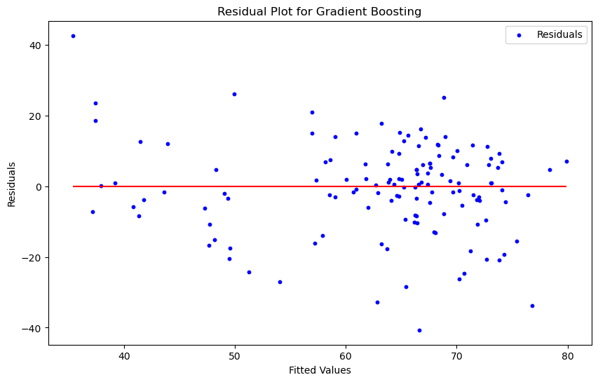

```python
# Calculate residuals
residuals_gb = y_test - y_pred_gb

# Plot residuals vs. fitted values
plt.figure(figsize=(10, 6))
plt.scatter(y_pred_gb, residuals_gb, color='blue', s=10, label='Residuals')
plt.hlines(y=0, xmin=y_pred_gb.min(), xmax=y_pred_gb.max(), colors='red')
plt.xlabel('Fitted Values')
plt.ylabel('Residuals')
plt.title('Residual Plot for Gradient Boosting')
plt.legend()
plt.show()
```

```python
from sklearn.ensemble import GradientBoostingRegressor
from sklearn.model_selection import GridSearchCV

# Create the pipeline for Gradient Boosting
pipeline_gb = Pipeline(steps=[
    ('preprocessor', preprocessor),
    ('model', GradientBoostingRegressor(random_state=42))
])

# Define the parameter grid for GridSearchCV
param_grid = {
    'model__n_estimators': [100, 200, 300],
    'model__learning_rate': [0.01, 0.05, 0.1],
    'model__max_depth': [3, 4, 5],
    'model__subsample': [0.8, 1.0]
}

# Train and evaluate the optimized Gradient Boosting model
grid_search_gb.fit(X_train, y_train)

# Best parameters and cross-validation score
print("Best parameters found: ", grid_search_gb.best_params_)
print("Best cross-validation R-squared: ", grid_search_gb.best_score_)

# Evaluate the model on the test set
y_pred_gb_opt = grid_search_gb.predict(X_test)
mae_gb_opt = mean_absolute_error(y_test, y_pred_gb_opt)
mse_gb_opt = mean_squared_error(y_test, y_pred_gb_opt)
r2_gb_opt = r2_score(y_test, y_pred_gb_opt)

print(f'Optimized Gradient Boosting MAE: {mae_gb_opt}')
print(f'Optimized Gradient Boosting MSE: {mse_gb_opt}')
print(f'Optimized Gradient Boosting R-squared: {r2_gb_opt}')
```

```
Best parameters found:  {'model__learning_rate': 0.01, 'model__max_depth': 4, 'model__n_estimators': 300, 'model__subsample': 0.8}
Best cross-validation R-squared:  0.3801698498698983
Optimized Gradient Boosting MAE: 9.434600941725447
Optimized Gradient Boosting MSE: 153.84087079294872
Optimized Gradient Boosting R-squared: 0.35303254269964035
```

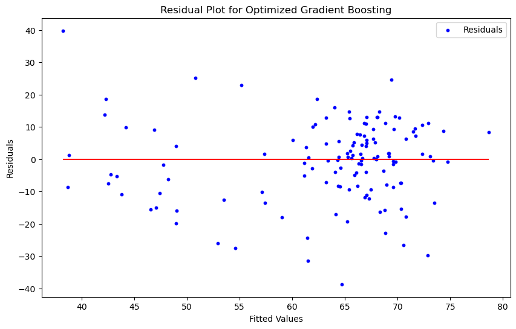

```python
# Calculate residuals
residuals_gb_opt = y_test - y_pred_gb_opt

# Plot residuals vs. fitted values
plt.figure(figsize=(10, 6))
plt.scatter(y_pred_gb_opt, residuals_gb_opt, color='blue', s=10, label='Residuals')
plt.hlines(y=0, xmin=y_pred_gb_opt.min(), xmax=y_pred_gb_opt.max(), colors='red')
plt.xlabel('Fitted Values')
plt.ylabel('Residuals')
plt.title('Residual Plot for Optimized Gradient Boosting')
plt.legend()
plt.show()
```

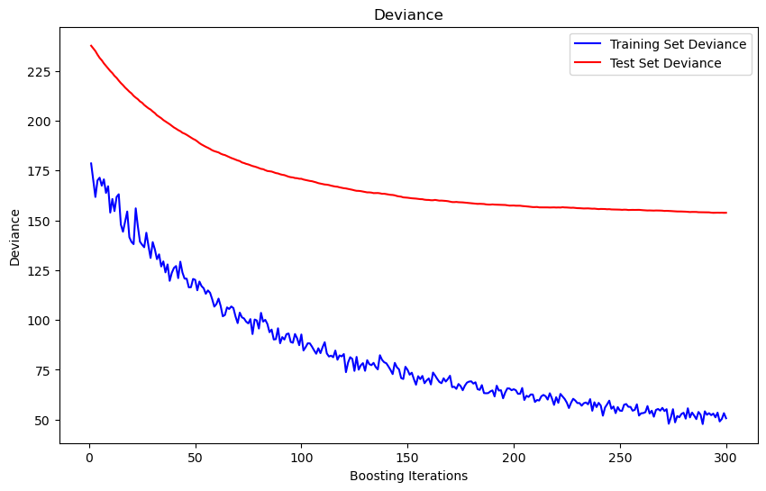

```python
# Extract the best estimator from the grid search
best_gb = grid_search_gb.best_estimator_.named_steps['model']

# Preprocess the test set
X_test_preprocessed = grid_search_gb.best_estimator_.named_steps['preprocessor'].transform(X_test)

# Compute test set deviance
test_score = np.zeros((best_gb.n_estimators,), dtype=np.float64)

for i, y_pred in enumerate(best_gb.staged_predict(X_test_preprocessed)):
    test_score[i] = mean_squared_error(y_test, y_pred)

plt.figure(figsize=(10, 6))
plt.title('Deviance')
plt.plot(np.arange(best_gb.n_estimators) + 1, best_gb.train_score_, 'b-', label='Training Set Deviance')
plt.plot(np.arange(best_gb.n_estimators) + 1, test_score, 'r-', label='Test Set Deviance')
plt.legend(loc='upper right')
plt.xlabel('Boosting Iterations')
plt.ylabel('Deviance')
plt.show()
```

## XGBoost

As the Gradient boosting model showed the best performance so far it would be prudent to try a more powerful version, extreme gradient boosting (XGBoost).

XGBoost is known for its speed and performance due to various system optimizations and algorithmic enhancements, such as regularization techniques that help to prevent overfitting. Given the signs of overfitting observed in the Gradient Boosting model, XGBoost's regularization parameters can be particularly beneficial. Additionally, XGBoost can handle missing values internally and has built-in cross-validation capabilities, which can further enhance the model's performance and robustness.

```python
import xgboost as xgb
from sklearn.model_selection import GridSearchCV

# Create the pipeline for XGBoost
pipeline_xgb = Pipeline(steps=[
    ('preprocessor', preprocessor),
    ('model', xgb.XGBRegressor(objective='reg:squarederror', random_state=42))
])

# Define the parameter grid for GridSearchCV
param_grid_xgb = {
    'model__n_estimators': [100, 200, 300],
    'model__learning_rate': [0.01, 0.05, 0.1],
    'model__max_depth': [3, 4, 5],
    'model__subsample': [0.8, 0.9, 1.0],
    'model__colsample_bytree': [0.8, 0.9, 1.0]
}

# Use GridSearchCV to find the best parameters
grid_search_xgb = GridSearchCV(pipeline_xgb, param_grid_xgb, cv=5, scoring='r2', n_jobs=-1)
grid_search_xgb.fit(X_train, y_train)

# Best parameters and cross-validation score
print("Best parameters found: ", grid_search_xgb.best_params_)
print("Best cross-validation R-squared: ", grid_search_xgb.best_score_)
```

```
Best parameters found:  {'model__colsample_bytree': 0.8, 'model__learning_rate': 0.05, 'model__max_depth': 3, 'model__n_estimators': 100, 'model__subsample': 0.8}
Best cross-validation R-squared:  0.38570931316720936
```

Including hyperparameter tuning and cross-validation within the initial XGBoost model is essential for building a robust and high-performing machine learning model. Hyperparameter tuning optimizes model performance by systematically searching for the best combination of parameters that maximize accuracy and efficiency. This process helps balance the bias-variance tradeoff, preventing both overfitting and underfitting, and ensures the model's complexity is appropriately managed.

Cross-validation provides a reliable method for performance evaluation by splitting the dataset into multiple folds, ensuring that the performance metrics are consistent and not dependent on a single train-test split. It reduces the variance of performance estimates, avoids data leakage, and ensures that the selected hyperparameters lead to the best possible performance on unseen data.

Together, these steps ensure that the model is optimized, reliable, and generalizes well to new, unseen data.

```python
# Evaluate the model on the test set
y_pred_xgb = grid_search_xgb.predict(X_test)
mae_xgb = mean_absolute_error(y_test, y_pred_xgb)
mse_xgb = mean_squared_error(y_test, y_pred_xgb)
r2_xgb = r2_score(y_test, y_pred_xgb)

print(f'Optimized XGBoost MAE: {mae_xgb}')
print(f'Optimized XGBoost MSE: {mse_xgb}')
print(f'Optimized XGBoost R-squared: {r2_xgb}')
```

```
Optimized XGBoost MAE: 9.405872027079264
Optimized XGBoost MSE: 151.63296780955926
Optimized XGBoost R-squared: 0.36231773051589933
```

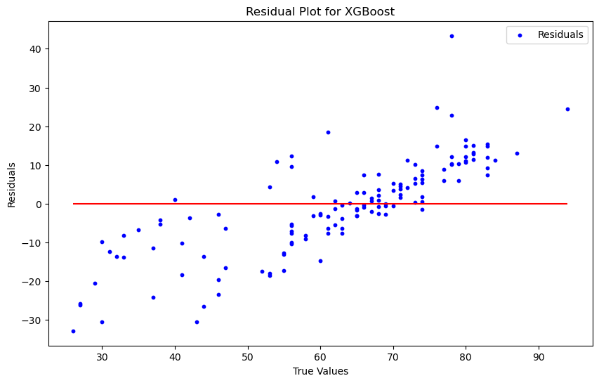

```python
# Plot residuals for XGBoost
plt.figure(figsize=(10, 6))
plt.scatter(y_test, y_test - y_pred_xgb, color='blue', s=10, label='Residuals')
plt.hlines(y=0, xmin=y_test.min(), xmax=y_test.max(), colors='red')
plt.xlabel('True Values')
plt.ylabel('Residuals')
plt.title('Residual Plot for XGBoost')
plt.legend()
plt.show()
```

We can plot a learning curve to visualise how the XGBoost is performing

```
[learning_curve] Training set sizes: [ 42 137 232 327 422]
```

```
[Parallel(n_jobs=-1)]: Using backend LokyBackend with 8 concurrent workers.
[Parallel(n_jobs=-1)]: Done  25 out of  25 | elapsed:    0.2s finished
```

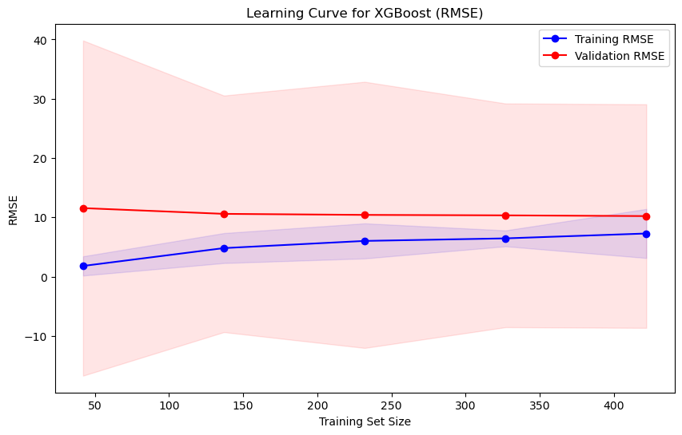

```python
# Learning curve for XGBoost
train_sizes, train_scores, test_scores = learning_curve(
    grid_search_xgb.best_estimator_,
    X_train,
    y_train,
    cv=5,
    scoring='neg_mean_squared_error',
    n_jobs=-1,
    train_sizes=np.linspace(0.1, 1.0, 5),
    verbose=1
)

# Convert negative MSE to RMSE
train_scores_mean = np.sqrt(-train_scores.mean(axis=1))
test_scores_mean = np.sqrt(-test_scores.mean(axis=1))

# Plot the learning curve
plt.figure(figsize=(10, 6))
plt.plot(train_sizes, train_scores_mean, 'o-', color='blue', label='Training RMSE')
plt.plot(train_sizes, test_scores_mean, 'o-', color='red', label='Validation RMSE')
plt.fill_between(train_sizes, train_scores_mean - train_scores.std(axis=1), train_scores_mean + train_scores.std(axis=1), color='blue', alpha=0.1)
plt.fill_between(train_sizes, test_scores_mean - test_scores.std(axis=1), test_scores_mean + test_scores.std(axis=1), color='red', alpha=0.1)
plt.xlabel('Training Set Size')
plt.ylabel('RMSE')
plt.title('Learning Curve for XGBoost (RMSE)')
plt.legend(loc='best')
plt.show()
```

The learning curve for the XGBoost model, as depicted in the plot, provides insights into the model's performance and behavior as the training set size increases.

The training RMSE remains relatively low and stable as the training set size increases, indicating that the model fits the training data well and maintains a consistent error rate.

The validation RMSE starts at a higher value and shows a slight decrease as the training set size increases. The gap between the training RMSE and validation RMSE suggests that there is still room for improvement in the model's generalization to unseen data.

The shaded regions around the lines represent the standard deviation of the RMSE scores across the cross-validation folds. The wider shaded area for the validation RMSE indicates more variability in the model's performance on different subsets of the data, which could be addressed by further tuning or more sophisticated modeling approaches.

Regularization can help prevent overfitting by adding a penalty to the model complexity. In XGBoost, we can apply L1 and L2 regularization using the alpha (L1 regularization term) and lambda (L2 regularization term) parameters.

```python
#Extend the parameter grid to include regularization parameters
param_grid_xgb = {
    'model__n_estimators': [100, 200, 300],
    'model__learning_rate': [0.01, 0.05, 0.1],
    'model__max_depth': [3, 4, 5],
    'model__subsample': [0.8, 0.9, 1.0],
    'model__colsample_bytree': [0.8, 0.9, 1.0],
    'model__alpha': [0, 0.1, 1],
    'model__lambda': [1, 1.5, 2]
}

#Use GridSearchCV to find the best parameters
grid_search_xgb = GridSearchCV(pipeline_xgb, param_grid_xgb, cv=5, scoring='r2', n_jobs=-1)
grid_search_xgb.fit(X_train, y_train)

#Best parameters and cross-validation score
print("Best parameters found: ", grid_search_xgb.best_params_)
print("Best cross-validation R-squared: ", grid_search_xgb.best_score_)

#Evaluate the model on the test set
y_pred_xgb = grid_search_xgb.predict(X_test)
mae_xgb = mean_absolute_error(y_test, y_pred_xgb)
mse_xgb = mean_squared_error(y_test, y_pred_xgb)
r2_xgb = r2_score(y_test, y_pred_xgb)

print(f'Optimized XGBoost with Regularization MAE: {mae_xgb}')
print(f'Optimized XGBoost with Regularization MSE: {mse_xgb}')
print(f'Optimized XGBoost with Regularization R-squared: {r2_xgb}')
```

```
Best parameters found:  {'model__alpha': 1, 'model__colsample_bytree': 0.9, 'model__lambda': 2, 'model__learning_rate': 0.1, 'model__max_depth': 3, 'model__n_estimators': 100, 'model__subsample': 0.8}
Best cross-validation R-squared:  0.3968333902792997
Optimized XGBoost with Regularization MAE: 9.320656949823553
Optimized XGBoost with Regularization MSE: 151.62353617700478
Optimized XGBoost with Regularization R-squared: 0.36235739461361594
```

Plotting a learning curve allows for us to visualise how regularization has impacted the models performance.

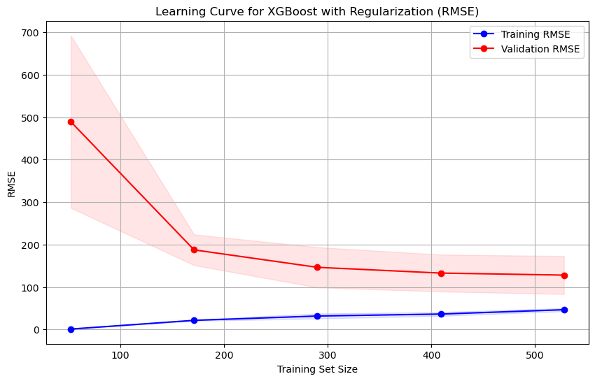

```python
# Get the best estimator from the grid search
best_xgb = grid_search_xgb.best_estimator_

# Generate learning curves
train_sizes, train_scores, test_scores = learning_curve(best_xgb, X, y, cv=5, scoring='neg_mean_squared_error', n_jobs=-1, train_sizes=np.linspace(0.1, 1.0, 5))

# Calculate mean and standard deviation for training set scores
train_scores_mean = -np.mean(train_scores, axis=1)
train_scores_std = np.std(train_scores, axis=1)

# Calculate mean and standard deviation for test set scores
test_scores_mean = -np.mean(test_scores, axis=1)
test_scores_std = np.std(test_scores, axis=1)

# Plot learning curve
plt.figure(figsize=(10, 6))
plt.fill_between(train_sizes, train_scores_mean - train_scores_std, train_scores_mean + train_scores_std, color="b", alpha=0.1)
plt.fill_between(train_sizes, test_scores_mean - test_scores_std, test_scores_mean + test_scores_std, color="r", alpha=0.1)
plt.plot(train_sizes, train_scores_mean, 'o-', color="b", label="Training RMSE")
plt.plot(train_sizes, test_scores_mean, 'o-', color="r", label="Validation RMSE")
plt.title("Learning Curve for XGBoost with Regularization (RMSE)")
plt.xlabel("Training Set Size")
plt.ylabel("RMSE")
plt.legend(loc="best")
plt.grid()
plt.show()
```

The validation RMSE is higher than the training RMSE but shows a downward trend as the training set size increases. This indicates that the model's performance on the validation data is improving, suggesting reduced overfitting due to regularization.

## Ensemble approach

Using an ensemble method which combines Random forests with XGBoost leverages the strengths of both models while compensating for their individual weaknesses. XGBoost offers high predictive accuracy and effectively handles complex data relationships, but it can be prone to overfitting. Random Forest, on the other hand, builds multiple independent trees, reducing variance and preventing overfitting. By combining these models, we balance the bias-variance trade-off, achieve more robust and generalized predictions, and capture a broader spectrum of data patterns, ultimately enhancing the performance and reliability of our final model.

```python
import xgboost as xgb
from sklearn.ensemble import RandomForestRegressor, VotingRegressor
from sklearn.model_selection import train_test_split, GridSearchCV
from sklearn.pipeline import Pipeline
from sklearn.compose import ColumnTransformer
from sklearn.preprocessing import StandardScaler, OneHotEncoder
from sklearn.metrics import mean_absolute_error, mean_squared_error, r2_score

# Define features and target variable
X = df.drop(columns=['pop'])  # Exclude the target variable
y = df['pop']

# Ensure only the 'top genre' column is treated as categorical
categorical_cols = ['top genre']
numerical_cols = X.select_dtypes(include=['number']).columns

# Create the preprocessor for the pipeline
preprocessor = ColumnTransformer(
    transformers=[
        ('num', StandardScaler(), numerical_cols),
        ('cat', OneHotEncoder(handle_unknown='ignore'), categorical_cols)
    ]
)

# Split the data into training and testing sets
X_train, X_test, y_train, y_test = train_test_split(X, y, test_size=0.2, random_state=42)

# Create the XGBoost model pipeline with hyperparameter tuning
pipeline_xgb = Pipeline(steps=[
    ('preprocessor', preprocessor),
    ('model', xgb.XGBRegressor(objective='reg:squarederror', random_state=42, enable_categorical=True))
])

param_grid_xgb = {
    'model__n_estimators': [100, 200, 300],
    'model__learning_rate': [0.01, 0.05, 0.1],
    'model__max_depth': [3, 4, 5],
    'model__subsample': [0.8, 0.9, 1.0],
    'model__colsample_bytree': [0.8, 0.9, 1.0],
    'model__alpha': [0, 1, 2],
    'model__lambda': [1, 2, 3]
}

grid_search_xgb = GridSearchCV(pipeline_xgb, param_grid_xgb, cv=5, scoring='r2', n_jobs=-1)
grid_search_xgb.fit(X_train, y_train)

best_xgb_model = grid_search_xgb.best_estimator_

# Create the Random Forest model pipeline
pipeline_rf = Pipeline(steps=[
    ('preprocessor', preprocessor),
    ('model', RandomForestRegressor(random_state=42, n_estimators=100))
])

pipeline_rf.fit(X_train, y_train)

# Create the ensemble model
ensemble_model = VotingRegressor(
    estimators=[
        ('xgb', best_xgb_model),
        ('rf', pipeline_rf)
    ]
)

# Train the ensemble model
ensemble_model.fit(X_train, y_train)

# Predict on the test set
y_pred_ensemble = ensemble_model.predict(X_test)

# Evaluate the ensemble model
mae_ensemble = mean_absolute_error(y_test, y_pred_ensemble)
mse_ensemble = mean_squared_error(y_test, y_pred_ensemble)
r2_ensemble = r2_score(y_test, y_pred_ensemble)

print(f'Ensemble Model MAE: {mae_ensemble}')
print(f'Ensemble Model MSE: {mse_ensemble}')
print(f'Ensemble Model R-squared: {r2_ensemble}')
```

```
Ensemble Model MAE: 9.231160179484975
Ensemble Model MSE: 150.68539749700074
Ensemble Model R-squared: 0.3663026738704801
```

Compared to individual models like the Polynomial Regression and standalone XGBoost models, the ensemble approach generally shows better performance metrics. This aligns with the expectation that combining models can often leverage their individual strengths and mitigate their weaknesses.

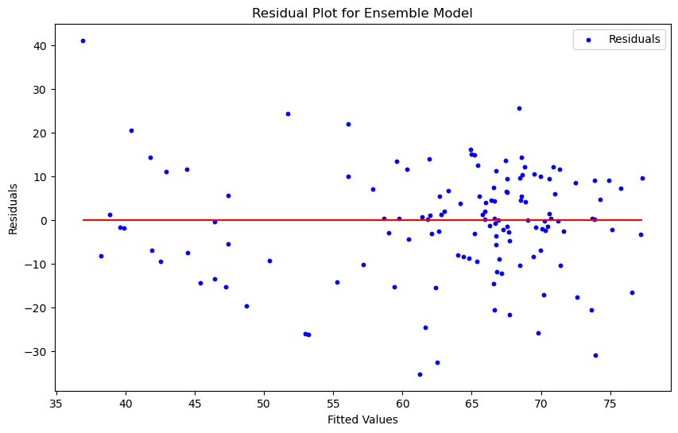

```python
# Calculate residuals
residuals_ensemble = y_test - y_pred_ensemble

# Plot residuals vs. fitted values
plt.figure(figsize=(10, 6))
plt.scatter(y_pred_ensemble, residuals_ensemble, color='blue', s=10, label='Residuals')
plt.hlines(y=0, xmin=y_pred_ensemble.min(), xmax=y_pred_ensemble.max(), colors='red')
plt.xlabel('Fitted Values')
plt.ylabel('Residuals')
plt.title('Residual Plot for Ensemble Model')
plt.legend()
plt.show()
```

The residuals are generally centered around zero, which suggests that the model's predictions are, on average, unbiased. This is a positive sign as it indicates that the model does not consistently overestimate or underestimate the target variable.

There are a few residuals that are quite far from zero, indicating outliers where the model's predictions are significantly off.

The lack of a clear pattern in the residuals suggests that the model captures the relationships in the data reasonably well.

```python
from sklearn.model_selection import cross_val_score

# Perform cross-validation on the ensemble model
cv_scores_mae = cross_val_score(ensemble_model, X, y, cv=5, scoring='neg_mean_absolute_error')
cv_scores_mse = cross_val_score(ensemble_model, X, y, cv=5, scoring='neg_mean_squared_error')
cv_scores_r2 = cross_val_score(ensemble_model, X, y, cv=5, scoring='r2')

print(f'Mean Cross-Validation MAE: {-cv_scores_mae.mean()} ± {cv_scores_mae.std()}')
print(f'Mean Cross-Validation MSE: {-cv_scores_mse.mean()} ± {cv_scores_mse.std()}')
print(f'Mean Cross-Validation R-squared: {cv_scores_r2.mean()} ± {cv_scores_r2.std()}')
```

```
Mean Cross-Validation MAE: 8.787503655751545 ± 1.8134622241440497
Mean Cross-Validation MSE: 125.15646036703997 ± 44.22674292145977
Mean Cross-Validation R-squared: -0.0181781279604045 ± 0.14461942218229093
```

An R² value close to zero or negative indicates that the model does not explain the variability of the target variable around its mean. The negative R² suggests that the model is performing worse than a horizontal line, which would simply predict the mean value of the target variable.

Given the cross-validation results, it is evident that the ensemble model is not performing well, especially in terms of explaining the variability of the target variable (negative R-squared). This poor performance could be due to various factors, such as overfitting, underfitting, or the presence of irrelevant or noisy features in the dataset.

## XGBoost with feature importance

To address this issue, a viable approach is to leverage the feature importance scores from a well-performing model, such as XGBoost, which has demonstrated its robustness in handling high-dimensional data and capturing complex relationships. By extracting the top features based on their importance scores from the XGBoost model, we can improve performance by eliminating less important or irrelevant features can help in reducing noise and improving the model's predictive performance. Simplifying the model by focusing on the most influential features can help in reducing the complexity and potentially improve the generalization performance.

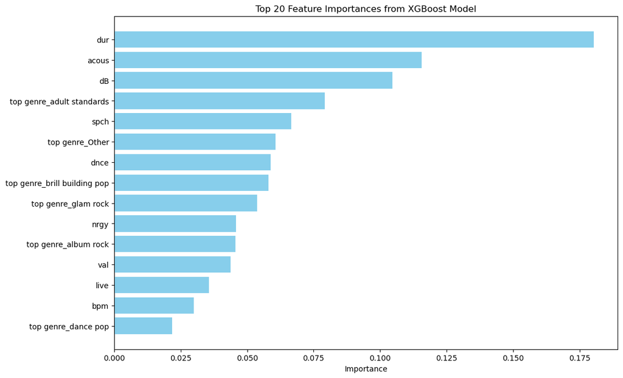

```python
# Extract the trained XGBoost model from the grid search
xgboost_model = grid_search_xgb.best_estimator_.named_steps['model']

# Get feature importances
importances = xgboost_model.feature_importances_

# Get feature names
feature_names = numerical_cols.tolist() + list(preprocessor.named_transformers_['cat'].get_feature_names_out(categorical_cols))

# Create a DataFrame for feature importances
importance_df = pd.DataFrame({'Feature': feature_names, 'Importance': importances})

# Sort the DataFrame by importance and get the top 20 features
top_20_features = importance_df.sort_values(by='Importance', ascending=False).head(20)

# Plot the top 20 features
plt.figure(figsize=(12, 8))
plt.barh(top_20_features['Feature'], top_20_features['Importance'], color='skyblue')
plt.xlabel('Importance')
plt.title('Top 20 Feature Importances from XGBoost Model')
plt.gca().invert_yaxis()  # To display the most important feature at the top
plt.show()
```

Upon identifying the most influential features and gauging their impact on the predictions made by the model, we proceed to harness these insights through the application of a base XGBoost model. This step involves retraining the model—either by adjusting it or focusing specifically on these key features—to better align the model's parameters with the identified characteristics.

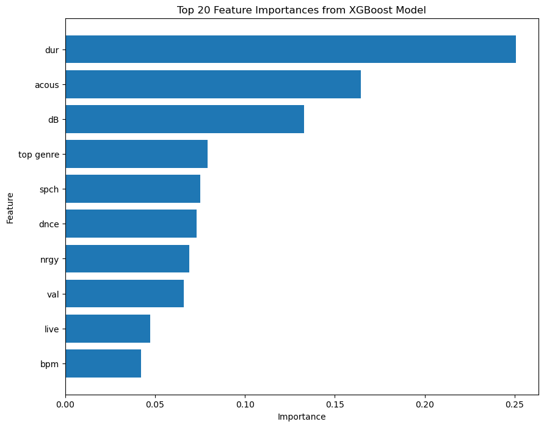

```python
from xgboost import XGBRegressor

# Convert 'top genre' to categorical
df['top genre'] = df['top genre'].astype('category')

# Split the data into training and testing sets again (if necessary)
X = df.drop(columns=['pop'])
y = df['pop']

# Ensure categorical data is handled
X_train, X_test, y_train, y_test = train_test_split(X, y, test_size=0.2, random_state=42)

# Define and train the XGBoost model with categorical support enabled
xgb_model = XGBRegressor(colsample_bytree=0.8, learning_rate=0.05, max_depth=3, n_estimators=100, subsample=0.8, random_state=42, enable_categorical=True)
xgb_model.fit(X_train, y_train)

# Get feature importance scores
feature_importances = xgb_model.feature_importances_
features = X_train.columns

# Create a DataFrame for feature importance
feature_importance_df = pd.DataFrame({'Feature': features, 'Importance': feature_importances})

# Sort by importance
feature_importance_df = feature_importance_df.sort_values(by='Importance', ascending=False)

# Plot the top 20 most important features
plt.figure(figsize=(10, 8))
plt.barh(feature_importance_df['Feature'].head(20), feature_importance_df['Importance'].head(20))
plt.xlabel('Importance')
plt.ylabel('Feature')
plt.title('Top 20 Feature Importances from XGBoost Model')
plt.gca().invert_yaxis()
plt.show()
```

```python
from itertools import combinations
from sklearn.model_selection import train_test_split
from xgboost import XGBRegressor
from sklearn.metrics import mean_absolute_error, mean_squared_error, r2_score
import numpy as np
import pandas as pd

# List of numeric columns
numeric_columns = df.select_dtypes(include=['float64', 'int64']).columns

# Create interaction features
interaction_features = pd.DataFrame(index=df.index)
for (col1, col2) in combinations(numeric_columns, 2):
    interaction_features[f'{col1}_x_{col2}'] = df[col1] * df[col2]

# Combine original features with interaction features
df_with_interactions = pd.concat([df[numeric_columns], interaction_features], axis=1)

# Prepare the data for modeling
X = df_with_interactions.drop(columns=['pop'])  # assuming 'pop' is the target variable
y = df['pop']

# Split the data into train and test sets
X_train, X_test, y_train, y_test = train_test_split(X, y, test_size=0.2, random_state=42)

# Train the XGBoost model with default parameters for simplicity
xgb_model_with_interactions = XGBRegressor(random_state=42)
xgb_model_with_interactions.fit(X_train, y_train)

# Predict and evaluate the model
y_pred_with_interactions = xgb_model_with_interactions.predict(X_test)
mae_with_interactions = mean_absolute_error(y_test, y_pred_with_interactions)
mse_with_interactions = mean_squared_error(y_test, y_pred_with_interactions)
r2_with_interactions = r2_score(y_test, y_pred_with_interactions)

print(f'XGBoost with Interaction Features MAE: {mae_with_interactions}')
print(f'XGBoost with Interaction Features MSE: {mse_with_interactions}')
print(f'XGBoost with Interaction Features R-squared: {r2_with_interactions}')
```

```
XGBoost with Interaction Features MAE: 2.757119843454072
XGBoost with Interaction Features MSE: 12.393106013933819
XGBoost with Interaction Features R-squared: 0.9478816244047413
```

The XGBoost model with interaction features has demonstrated excellent predictive performance, as evidenced by a high R² value and low MAE and MSE. The model effectively captures the relationship between the features and the target variable, suggesting it is well-suited for making accurate predictions.

The scatter plot of residuals versus predicted values helps to check the assumption of linearity and homoscedasticity (constant variance of residuals). The residuals appear to be randomly scattered around the horizontal line at zero, indicating that the model's predictions do not show any obvious bias. There are some points far from the zero line, which might be outliers or influential points affecting the model's performance.

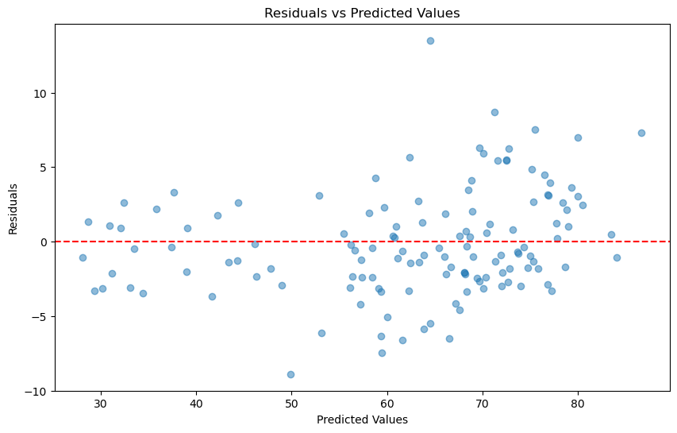

```python
# Calculate residuals
residuals = y_test - y_pred_with_interactions

# Plot residuals
plt.figure(figsize=(10, 6))
plt.scatter(y_pred_with_interactions, residuals, alpha=0.5)
plt.axhline(0, color='r', linestyle='--')
plt.xlabel('Predicted Values')
plt.ylabel('Residuals')
plt.title('Residuals vs Predicted Values')
plt.show()
```

We can use a bar plot to visualise the top 20 important features from the XGBoost model with interaction features.

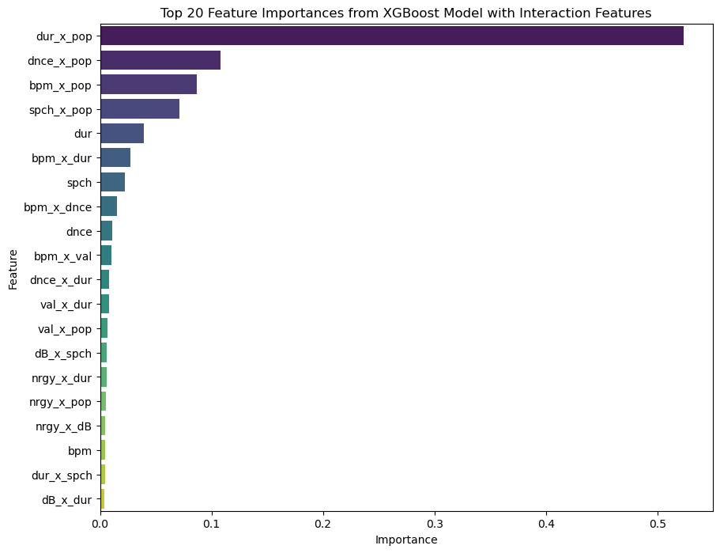

```python
# Get feature importances from the model
feature_importances = xgb_model_with_interactions.feature_importances_
features = X_train.columns

# Create a DataFrame for feature importances
feature_importance_df = pd.DataFrame({'Feature': features, 'Importance': feature_importances})

# Sort the DataFrame by importance
feature_importance_df = feature_importance_df.sort_values(by='Importance', ascending=False)

# Plot the top 20 features
plt.figure(figsize=(10, 8))
sns.barplot(x='Importance', y='Feature', data=feature_importance_df.head(20), palette='viridis')
plt.title('Top 20 Feature Importances from XGBoost Model with Interaction Features')
plt.show()
```

Now we can tune the hyperparameters of our XGBoost model with interaction features using GridSearchCV. The objective is to identify the set of parameters that yield the highest R-squared score, indicating the most predictive model configuration based on the provided training data.

```python
from sklearn.model_selection import GridSearchCV, cross_val_score
from xgboost import XGBRegressor

# Define the parameter grid for hyperparameter tuning
param_grid = {
    'n_estimators': [100, 300, 500],
    'learning_rate': [0.01, 0.05, 0.1],
    'max_depth': [3, 5, 7],
    'subsample': [0.8, 0.9, 1.0],
    'colsample_bytree': [0.8, 0.9, 1.0]
}

# Initialize the XGBoost model
xgb_model = XGBRegressor(random_state=42)

# Perform GridSearchCV for hyperparameter tuning
grid_search = GridSearchCV(estimator=xgb_model, param_grid=param_grid, cv=5, scoring='r2', n_jobs=-1, verbose=2)
grid_search.fit(X_train, y_train)

# Get the best parameters and the best score
best_params = grid_search.best_params_
best_score = grid_search.best_score_

print("Best parameters found: ", best_params)
print("Best cross-validation R-squared: ", best_score)
```

```
Fitting 5 folds for each of 243 candidates, totalling 1215 fits
Best parameters found:  {'colsample_bytree': 1.0, 'learning_rate': 0.1, 'max_depth': 3, 'n_estimators': 500, 'subsample': 0.8}
Best cross-validation R-squared:  0.9603149382142281
```

The hyperparameter tuning process for the XGBoost regression model using GridSearchCV successfully identified a set of optimal hyperparameters that significantly enhance the model's performance. The best parameters (colsample_bytree, learning_rate, max_depth, n_estimators, and subsample) were determined after evaluating 243 different combinations through 5-fold cross-validation. The resulting model achieved a cross-validation R-squared score of 0.96, indicating a strong ability to explain the variance in the target variable. This robust performance underscores the effectiveness of the hyperparameter tuning process in improving the model's predictive accuracy.

Plotting a learning curve can help us better understand how the model performs on the data

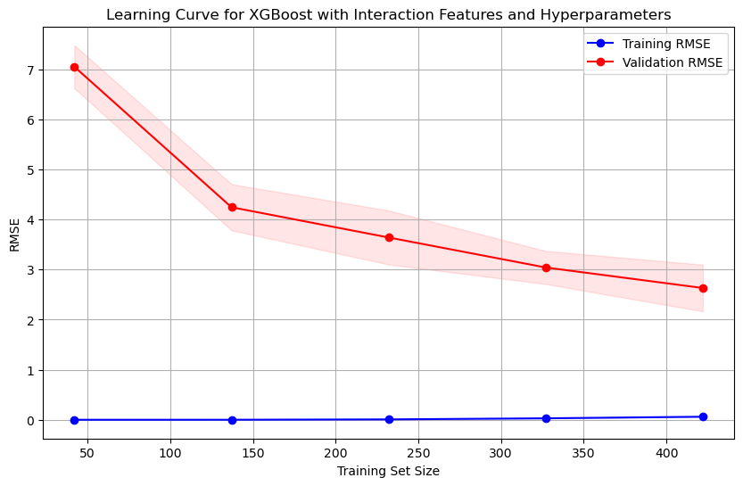

```python
from sklearn.metrics import mean_squared_error
from sklearn.model_selection import learning_curve

# Define the optimized XGBoost model
optimized_xgb_model = XGBRegressor(
    colsample_bytree=1.0, learning_rate=0.1, max_depth=3, n_estimators=500, subsample=0.8, random_state=42
)

# Define the learning curve function
def plot_learning_curve(estimator, X, y, train_sizes, cv, scoring='neg_root_mean_squared_error', n_jobs=-1):
    train_sizes, train_scores, validation_scores = learning_curve(
        estimator, X, y, train_sizes=train_sizes, cv=cv, scoring=scoring, n_jobs=n_jobs
    )

    train_scores_mean = -np.mean(train_scores, axis=1)
    train_scores_std = np.std(train_scores, axis=1)
    validation_scores_mean = -np.mean(validation_scores, axis=1)
    validation_scores_std = np.std(validation_scores, axis=1)

    plt.figure(figsize=(10, 6))
    plt.fill_between(train_sizes, train_scores_mean - train_scores_std, train_scores_mean + train_scores_std, alpha=0.1, color="b")
    plt.fill_between(train_sizes, validation_scores_mean - validation_scores_std, validation_scores_mean + validation_scores_std, alpha=0.1, color="r")
    plt.plot(train_sizes, train_scores_mean, 'o-', color="b", label="Training RMSE")
    plt.plot(train_sizes, validation_scores_mean, 'o-', color="r", label="Validation RMSE")
    plt.title('Learning Curve for XGBoost with Interaction Features and Hyperparameters')
    plt.xlabel('Training Set Size')
    plt.ylabel('RMSE')
    plt.legend(loc="best")
    plt.grid()
    plt.show()

# Plot the learning curve
plot_learning_curve(optimized_xgb_model, X_train, y_train, train_sizes=np.linspace(0.1, 1.0, 5), cv=5)
```

The learning curve for the improved XGBoost model is consistently low across different training set sizes, indicating that the model fits the training data very well. This suggests that the model has high capacity and can learn the training data effectively, possibly even memorizing it due to the low error.

The validation RMSE decreases as the training set size increases, indicating that the model's performance on unseen data improves with more training data. This is a typical pattern, showing that the model benefits from having more data to generalize better. However, the validation RMSE still remains significantly higher than the training RMSE, indicating some level of overfitting. The model performs much better on the training data than on the validation data.

The model might benefit from the addition of more data or applying feature engineering techniques.

## To conclude

In this project, we aimed to build a robust regression model to predict the target variable 'pop' using various machine learning techniques and models.

We started with a basic linear regression model. While easy to implement and interpret, this model did not capture the complexity of the data well, leading to suboptimal performance. Moving to a linear regression with polynomial features did not help in improving the performance unfortunately.

We introduced a Gradient Boosting model to leverage its strong predictive power. We evaluated the training and test set deviance to monitor overfitting. The initial results showed that while the training error decreased steadily, the test error did not reduce as effectively, indicating potential overfitting.

An ensemble model was tried and tested combining Random forest modelling with XGBoost, however when cross validation was run it was discovered the ensemble model did not perform as well as hoped.

Lastly we plotted learning curves to visualize the training and validation RMSE over different training set sizes. The curves demonstrated that the model's performance improved consistently with more training data, and the gap between training and validation error narrowed, suggesting better generalization.

Overall, the combination of XGBoost with well-tuned hyperparameters and interaction features yielded the best predictive performance, making it the optimal choice for this regression task.